# CHD1 CUT&RUN analysis for Chd1R616Q NPCs

Kimberley Jade Anderson

2026-06-28

# 1 Overview

This R Markdown contains the CHD1 CUT&RUN analysis steps relevant to the manuscript figures and statements:

- Bowtie2 alignment-rate summary
- Peak-calling workflow documentation
- DiffBind setup and consensus CHD1 peakset generation
- Peak annotation
- Overlap between CHD1-bound genes and the top RNA-seq p-value decile
- Export of gene lists used for downstream interpretation

Exploratory analyses and unused sections have been removed.

# 2 Libraries

```r
library(tidyverse)
library(knitr)
library(kableExtra)
library(DiffBind)
library(ChIPseeker)
library(TxDb.Mmusculus.UCSC.mm10.ensGene)
library(org.Mm.eg.db)
library(Mus.musculus)
library(VennDiagram)
library(GeneOverlap)

txdb <- TxDb.Mmusculus.UCSC.mm10.ensGene
```

# 3 Alignment QC

The original FASTQ processing, Bowtie2 alignment, SAM/BAM conversion, bigWig generation, and MACS3 peak calling were performed outside R. The commands are retained here for reproducibility but are not evaluated during knitting.

```bash
# Run FastQC
find . -maxdepth 1 -mindepth 1 -type d -exec sh -c "cd '{}' && pwd && fastqc *.fastq.gz -t 90" \;

# Align paired-end reads to mm10 using Bowtie2
find . -maxdepth 1 -mindepth 1 -type d -exec sh -c "cd '{}' && \
  bowtie2 -p 40 --time --met-stderr --met-file bt2_metrics.txt \
  -x /hpcdata/Mimir/kimberl/mm10_bt2/mm10 \
  -1 '{$1}'_L008_R1_001.fastq.gz \
  -2 '{$1}'_L008_R2_001.fastq.gz \
  -S '{$1}'.sam" \;
```

```bash
# Convert SAM files to coordinate-sorted BAM files
for i in `ls */*.sam | rev | cut -c 5- | rev | uniq`
do
  samtools view -@ 16 -bS ${i}.sam | \
  samtools sort -T ${i} -O BAM -@ 16 -o ${i}.bam
done
```

```bash
# Merge IgG files for shared control
samtools merge -o all_merged_IgGs.bam -@ 48 *IgG*.bam

# Activate MACS3 environment
ml load Anaconda3/2022.05
conda activate /hpcapps/env/conda/MACS3

# Call CHD1 peaks against merged IgG control
for i in `ls *CHD1*.bam | rev | cut -c 5- | rev | uniq`
do
  echo "Calling peaks for sample: $i"
  macs3 callpeak \
    -t ${i}.bam \
    -c all_merged_IgGs.bam \
    -n ${i} \
    -f BAMPE \
    -g mm \
    --outdir ${i} \
    -q 0.1 \
    --max-gap 300 \
    --keep-dup all
done
```

## 3.1 Bowtie2 alignment-rate table

```r
bt2_file <- "20240411_bt2_output.txt"

bt2_lines <- readLines(bt2_file)

alignment.table <- tibble(line = bt2_lines) %>%
  mutate(
    is_sample = str_detect(line, "^/"),
    sample = if_else(is_sample, basename(line), NA_character_)
  ) %>%
  tidyr::fill(sample) %>%
  filter(str_detect(sample, regex("CHD1|IgG", ignore_case = TRUE))) %>%
  filter(str_detect(line, "overall alignment rate")) %>%
  mutate(
    alignment_rate = str_extract(
      line,
      "\\d+\\.\\d+(?=% overall alignment rate)"
    ) %>% as.numeric()
  ) %>%
  dplyr::select(sample, alignment_rate) %>%
  arrange(sample)

alignment.table %>%
  kable(
    caption = "Bowtie2 overall alignment rates for CHD1 and IgG CUT&RUN samples",
    col.names = c("Sample", "Overall alignment rate (%)"),
    digits = 2
  ) %>%
  kable_styling(
    bootstrap_options = c("striped", "hover", "condensed"),
    full_width = FALSE
  )
```

Bowtie2 overall alignment rates for CHD1 and IgG CUT&RUN samples

| Sample | Overall alignment rate (%) |
| --- | --- |
| 1470-1_DMSO_CHD1_S10 | 95.95 |
| 1470-3_DHT_CHD1_S16 | 95.97 |
| 1470-3_DMSO_CHD1_S13 | 96.25 |
| 1470-3_DMSO_IgG_S25 | 83.91 |
| 2288-2_DHT_CHD1_S26 | 94.34 |
| 2288-2_DHT_IgG_S31 | 78.97 |
| 2288-2_DMSO_CHD1_S22 | 94.30 |
| 2288-2_DMSO_IgG_S24 | 88.25 |
| 2288-5_DHT_CHD1_S7 | 93.10 |
| 2288-5_DHT_IgG_S19 | 92.78 |
| 2288-5_DMSO_CHD1_S4 | 93.63 |
| 2288-5_DMSO_IgG_S18 | 88.29 |
| 2288-6_DMSO_CHD1_S19 | 94.00 |
| 2288-6_DMSO_IgG_S23 | 88.70 |
| 2288-8_DMSO_CHD1_S1 | 92.91 |
| 2288-8_DMSO_IgG_S17 | 86.29 |

```r
write.csv(
  alignment.table,
  "CHD1_CUTRUN_bowtie2_alignment_rates.csv",
  row.names = FALSE
)
```

# 4 BigWig files and TSS profiles

These commands generate normalized bigWig files and CHD1 signal profiles over transcription start sites. They are retained as documentation of the figure-generation workflow.

```bash
module load deepTools
module load SAMtools

samtools index -M *merged.bam

# Generate RPGC-normalized bigWig files
for i in `ls *merged.bam | rev | cut -c 5- | rev | uniq`
do
  bamCoverage \
    --bam ${i}.bam \
    -o ${i}_depthnorm.bw \
    -p max \
    --binSize 5 \
    --smoothLength 30 \
    --normalizeUsing RPGC \
    --effectiveGenomeSize 2652783500 \
    --ignoreForNormalization chrX \
    --minFragmentLength 130 \
    --extendReads \
    --centerReads
done

# Signal over TSSs
computeMatrix reference-point \
  --referencePoint TSS \
  -o CHD1_overTSSs \
  -S 20240816_CHD1_WT_DMSO_merged_depthnorm.bw \
     20240816_CHD1_R616Q_DMSO_merged_depthnorm.bw \
     20240816_CHD1_R616Q_DHT_merged_depthnorm.bw \
  -R mm10_transcripts.bed \
  -a 3000 \
  -b 3000 \
  -p 24 \
  --samplesLabel WT Mut_DMSO Mut_DHT

plotProfile -m CHD1_overTSSs -o CHD1_overTSSs.pdf
plotProfile -m CHD1_overTSSs -o CHD1_overTSSs_olap.pdf --plotType overlapped_lines
```

# 5 DiffBind sample sheet

```r
samples <- list.dirs("Peak_calling/", full.names = FALSE, recursive = FALSE)

diffbind.samplesheet <- data.frame(
  SampleID = samples[grepl("CHD1", samples)]
)

diffbind.samplesheet <- diffbind.samplesheet %>%
  tidyr::separate_wider_delim(
    SampleID,
    delim = "_",
    names = c("Embryo", "Treatment", "Factor", "Sample"),
    cols_remove = FALSE
  )

genotypes <- read.csv2("Genotypes.csv")

diffbind.samplesheet <- dplyr::left_join(
  diffbind.samplesheet,
  genotypes,
  by = NULL
)

# Check what the genotype column is called
names(diffbind.samplesheet)
```

```
## [1] "Embryo"    "Treatment" "Factor"    "Sample"    "SampleID"  "Genotype"
```

```r
# Rename columns safely
if ("Genotype" %in% names(diffbind.samplesheet)) {
  diffbind.samplesheet <- diffbind.samplesheet %>%
    dplyr::rename(Condition = Genotype)
}

if ("Embryo" %in% names(diffbind.samplesheet)) {
  diffbind.samplesheet <- diffbind.samplesheet %>%
    dplyr::rename(Tissue = Embryo)
}

if ("Sample" %in% names(diffbind.samplesheet)) {
  diffbind.samplesheet <- diffbind.samplesheet %>%
    dplyr::select(-Sample)
}

diffbind.samplesheet <- diffbind.samplesheet %>%
  dplyr::mutate(
    bamReads = paste0("bam_files/", SampleID, ".bam"),
    controlID = "all_merged_IgGs",
    bamControl = "bam_files/all_merged_IgGs.bam",
    Peaks = paste0("Peak_calling/", SampleID, "/", SampleID, "_peaks.xls"),
    PeakCaller = "macs"
  )

write.csv(
  diffbind.samplesheet,
  "diffBind_sampleSheet_generated.csv",
  row.names = FALSE
)

diffbind.samplesheet
```

```
## # A tibble: 9 × 10
##   Tissue Treatment Factor SampleID Condition bamReads controlID bamControl Peaks
##   <chr>  <chr>     <chr>  <chr>    <chr>     <chr>    <chr>     <chr>      <chr>
## 1 1470-1 DMSO      CHD1   1470-1_… Chd1+/R6… bam_fil… all_merg… bam_files… Peak…
## 2 1470-3 DHT       CHD1   1470-3_… Chd1+/+   bam_fil… all_merg… bam_files… Peak…
## 3 1470-3 DMSO      CHD1   1470-3_… Chd1+/+   bam_fil… all_merg… bam_files… Peak…
## 4 2288-2 DHT       CHD1   2288-2_… Chd1+/R6… bam_fil… all_merg… bam_files… Peak…
## 5 2288-2 DMSO      CHD1   2288-2_… Chd1+/R6… bam_fil… all_merg… bam_files… Peak…
## 6 2288-5 DHT       CHD1   2288-5_… Chd1+/R6… bam_fil… all_merg… bam_files… Peak…
## 7 2288-5 DMSO      CHD1   2288-5_… Chd1+/R6… bam_fil… all_merg… bam_files… Peak…
## 8 2288-6 DMSO      CHD1   2288-6_… Chd1+/+   bam_fil… all_merg… bam_files… Peak…
## 9 2288-8 DMSO      CHD1   2288-8_… Chd1+/+   bam_fil… all_merg… bam_files… Peak…
## # ℹ 1 more variable: PeakCaller <chr>
```

# 6 DiffBind analysis

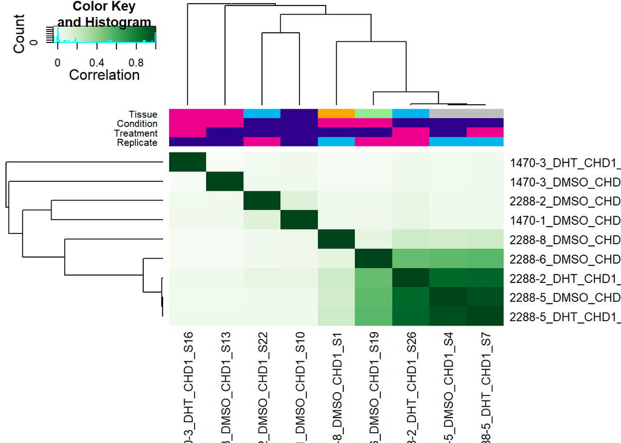

```r
final.samplesheet <- read.csv2("diffBind_sampleSheet_1.csv") %>%
  filter(str_detect(SampleID, "CHD1"))

dba.all <- dba(sampleSheet = final.samplesheet)
plot(dba.all)
```

```r
dba.all <- dba.count(dba.all)
```

```r
# Remove blacklist regions and generate/apply greylist
dba.all <- dba.blacklist(dba.all, greylist = FALSE)

# Normalize using native DiffBind methods with background signal
chd1.norm.background <- dba.normalize(
  dba.all,
  method = DBA_ALL_METHODS,
  normalize = DBA_NORM_NATIVE,
  background = TRUE
)

# Test for differential occupancy by condition
chd1.dba <- dba.analyze(
  chd1.norm.background,
  method = DBA_ALL_METHODS,
  design = "~Condition"
)
```

```
## coverage: 2872810 bp (0.11%)
```

```r
dba.show(chd1.dba, bContrasts = TRUE)
```

```
##      Factor   Group Samples           Group2 Samples2 DB.edgeR DB.DESeq2
## 1 Condition Chd1+/+       4 Chd1+/R616Q(g17)        5        0         0
```

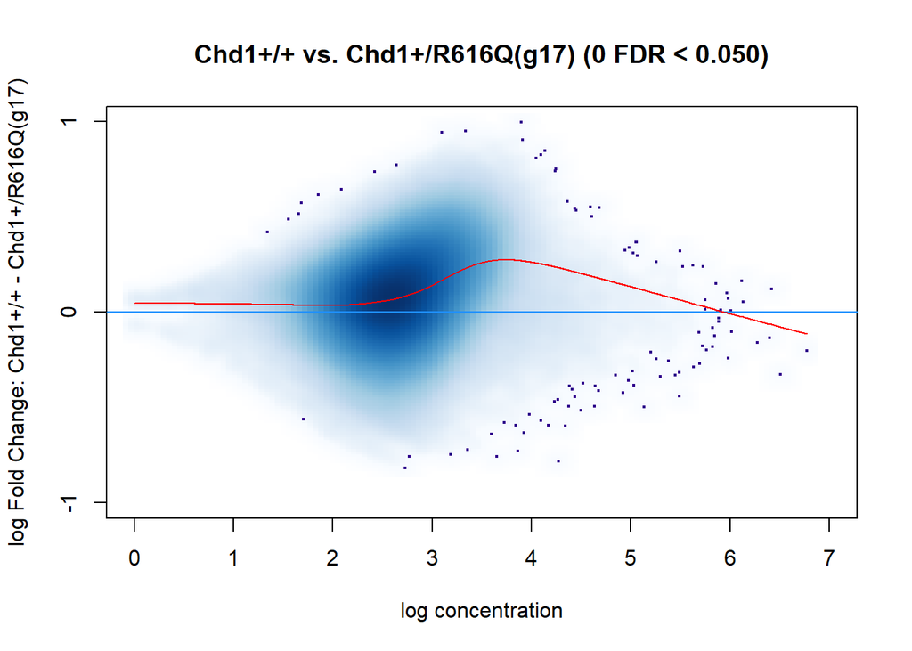

```r
# Diagnostic plots
dba.plotMA(chd1.dba, contrast = 1, method = DBA_DESEQ2)
```

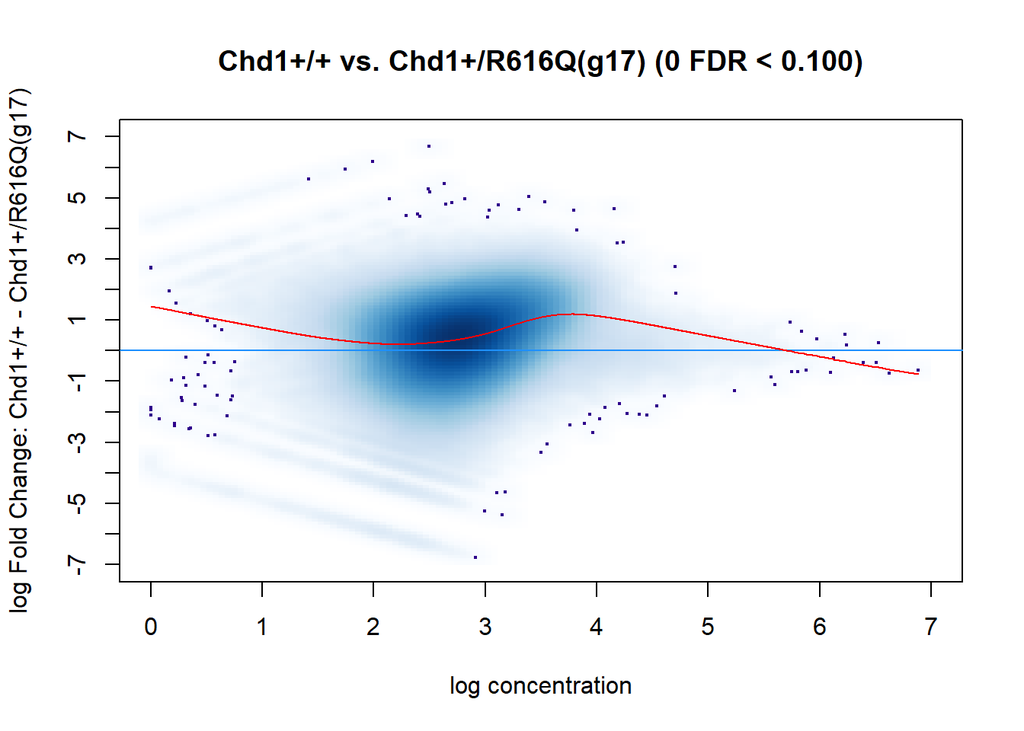

```r
dba.plotMA(chd1.dba, contrast = 1, method = DBA_EDGER, bNormalized = TRUE, th = 0.1)
```

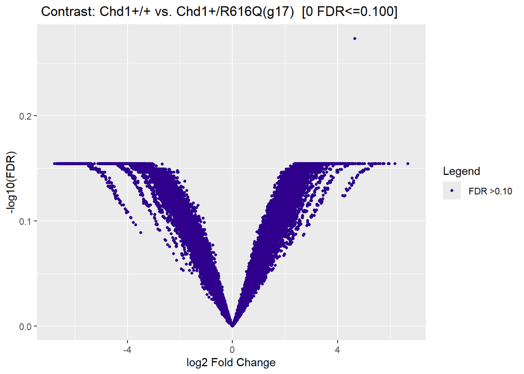

```r
dba.plotVolcano(chd1.dba, contrast = 1, method = DBA_EDGER, th = 0.1)
```

```r
# Export all tested sites
chd1.diff.peaks <- dba.report(chd1.dba, th = 1, method = DBA_EDGER)
chd1.diff.peaks.df <- as.data.frame(chd1.diff.peaks)

write.csv(
  chd1.diff.peaks.df,
  "CHD1_diffPeaks_all_tested_sites.csv",
  row.names = FALSE
)

# Retrieve WT DMSO consensus peaks
chd1.wt.peaks <- dba.peakset(
  chd1.dba,
  chd1.dba$masks$`Chd1+/+` & chd1.dba$masks$DMSO,
  bRetrieve = TRUE,
  DataType = DBA_DATA_FRAME
)

write.table(
  chd1.wt.peaks[, 1:3],
  "CHD1_WT_DMSO_consensus_peaks.bed",
  col.names = FALSE,
  row.names = FALSE,
  sep = "\t",
  quote = FALSE
)
```

# 7 Merged WT CHD1 peakset

For the manuscript, the CHD1-bound gene list was generated from merged WT DMSO CHD1 peaks, filtered by MACS score.

```r
merged.wt.peaks <- read.table(
  "Merged_CHD1_peaks/20240816_CHD1_WT_DMSO_merged_q01/20240816_CHD1_WT_DMSO_merged_peaks.narrowPeak",
  header = FALSE
)

# MACS narrowPeak column 5 is the score.
merged.wt.peaks.filtered <- merged.wt.peaks %>%
  filter(V5 > 100)

write.table(
  merged.wt.peaks.filtered[, 1:4],
  "merged_WT_CHD1_peaks_filtered.bed",
  col.names = FALSE,
  row.names = FALSE,
  quote = FALSE,
  sep = "\t"
)
```

# 8 Annotate CHD1 peaks

```r
raw <- read.table(
  "Merged_CHD1_peaks/20240816_CHD1_WT_DMSO_merged_q01/20240816_CHD1_WT_DMSO_merged_peaks.narrowPeak",
  header = FALSE
)

cat("Score quantiles:\n")
```

```
## Score quantiles:
```

```r
print(quantile(raw$V5, probs = c(0, 0.1, 0.25, 0.5, 0.75, 0.9, 1)))
```

```
##   0%  10%  25%  50%  75%  90% 100%
##   20   32   48   76  123  188 2298
```

```r
cat("\nPeaks with V5 > 200:", sum(raw$V5 > 200), "\n")
```

```
##
## Peaks with V5 > 200: 29288
```

```r
cat("\nPeaks with V5 > 100:", sum(raw$V5 > 100), "\n")
```

```
##
## Peaks with V5 > 100: 127955
```

```r
cat("Peaks with V5 > 50:", sum(raw$V5 > 50), "\n")
```

```
## Peaks with V5 > 50: 251803
```

```r
cat("Peaks with V5 > 10:", sum(raw$V5 > 10), "\n")
```

```
## Peaks with V5 > 10: 351749
```

```r
cat("Total peaks:", nrow(raw), "\n")
```

```
## Total peaks: 351749
```

This will show us whether `V5 > 200` is genuinely filtering out a meaningful proportion of peaks or whether almost all peaks already exceed that threshold.

```
## >> loading peak file...               2026-06-28 1:31:03 PM
## >> preparing features information...      2026-06-28 1:31:05 PM
## >> identifying nearest features...        2026-06-28 1:31:05 PM
## >> calculating distance from peak to TSS...   2026-06-28 1:31:07 PM
## >> assigning genomic annotation...        2026-06-28 1:31:07 PM
## >> adding gene annotation...          2026-06-28 1:31:16 PM
```

```
## >> assigning chromosome lengths           2026-06-28 1:31:17 PM
## >> done...                    2026-06-28 1:31:17 PM
```

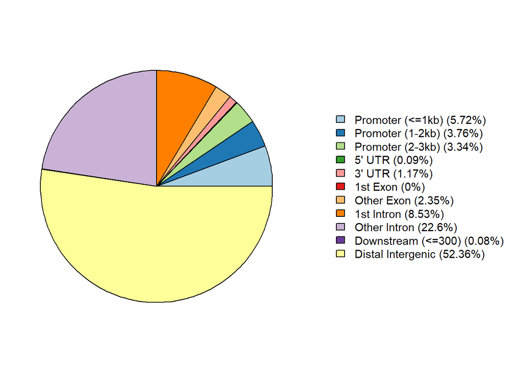

```r
anno_function <- function(bedfile) {
  cuttag_anno <- annotatePeak(
    bedfile,
    TxDb = txdb,
    annoDb = "Mus.musculus"
  )
  plotAnnoPie(cuttag_anno)
  as.data.frame(cuttag_anno)
}

CHD1_WT_peaks_anno <- anno_function("Merged_CHD1_peaks/20240816_CHD1_WT_DMSO_merged_q01/20240816_CHD1_WT_DMSO_merged_peaks.narrowPeak")
```

```r
nrow(CHD1_WT_peaks_anno)
```

```
## [1] 351705
```

```r
#Limit CHD1 peaks to only with score over 200
CHD1_WT_peaks_anno <- CHD1_WT_peaks_anno[CHD1_WT_peaks_anno$V5 >200,]
nrow(CHD1_WT_peaks_anno)
```

```
## [1] 29285
```

```r
write.table(CHD1_WT_peaks_anno[,c(1:4)], "merged_WT_CHD1_peaks_filtered.bed",
                col.names = FALSE, row.names = FALSE, quote = FALSE, sep = "\t")
CHD1_WT_peaks_anno <- anno_function("merged_WT_CHD1_peaks_filtered.bed")
```

```
## >> loading peak file...               2026-06-28 1:31:18 PM
## >> preparing features information...      2026-06-28 1:31:18 PM
## >> identifying nearest features...        2026-06-28 1:31:18 PM
## >> calculating distance from peak to TSS...   2026-06-28 1:31:18 PM
## >> assigning genomic annotation...        2026-06-28 1:31:18 PM
## >> adding gene annotation...          2026-06-28 1:31:19 PM
```

```
## >> assigning chromosome lengths           2026-06-28 1:31:19 PM
## >> done...                    2026-06-28 1:31:19 PM
```

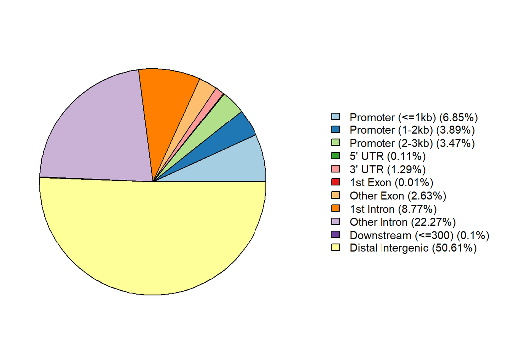

```r
cat("Peaks after filter:", nrow(CHD1_WT_peaks_anno), "\n")
```

```
## Peaks after filter: 29285
```

```r
cat("Unique genes:", n_distinct(CHD1_WT_peaks_anno$SYMBOL), "\n")
```

```
## Unique genes: 11163
```

```r
# DEGs
genotype_DEGs <- read.csv("20231116_Chd1_NPC_genotype_DEGs.csv")
genotype_DEGs$pval.decile <- ntile(genotype_DEGs$cor.pval, 10)
genotype_DEGs_top.dec <- genotype_DEGs %>% filter(pval.decile == 1)

# Unique gene sets
chd1.bound.genes <- CHD1_WT_peaks_anno %>%
  filter(!is.na(SYMBOL), SYMBOL != "") %>%
  distinct(SYMBOL)

deg.top.genes <- genotype_DEGs_top.dec %>%
  filter(!is.na(gene), gene != "") %>%
  distinct(gene)

overlap.genes <- intersect(CHD1_WT_peaks_anno$SYMBOL, deg.top.genes$gene)

cat("CHD1-bound genes:", nrow(chd1.bound.genes), "\n")
```

```
## CHD1-bound genes: 11162
```

```r
cat("Top decile DEGs:", nrow(deg.top.genes), "\n")
```

```
## Top decile DEGs: 1809
```

```r
cat("Overlap:", length(overlap.genes), "\n")
```

```
## Overlap: 752
```

# 9 Overlap between CHD1-bound genes and RNA-seq results

This analysis asks how many genes in the top p-value decile from the genotype RNA-seq comparison are directly associated with CHD1 CUT&RUN peaks.

```r
overlap.genes <- intersect(chd1.bound.genes$SYMBOL, deg.top.genes$gene)

cat("CHD1-bound genes:", nrow(chd1.bound.genes), "\n")
```

```
## CHD1-bound genes: 11162
```

```r
cat("Top decile DEGs:", nrow(deg.top.genes), "\n")
```

```
## Top decile DEGs: 1809
```

```r
cat("Overlap:", length(overlap.genes), "\n")
```

```
## Overlap: 752
```

## 9.1 Venn diagram

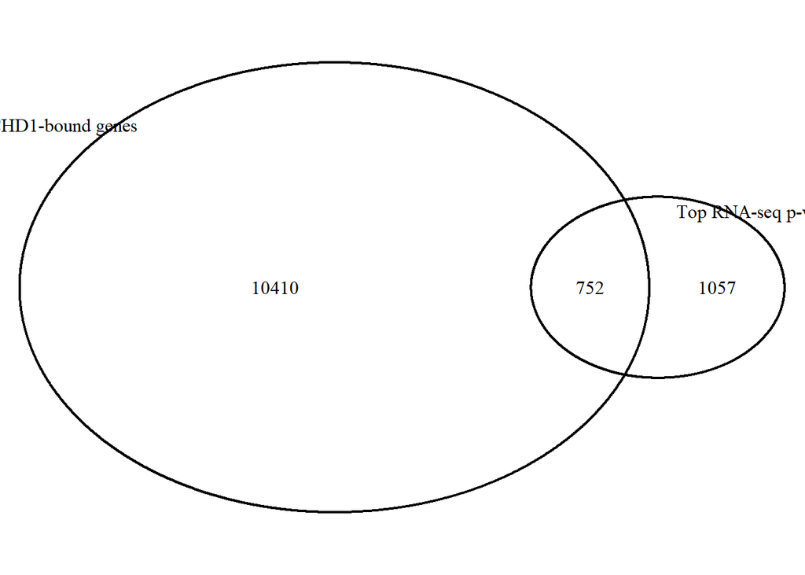

```r
chd1.rnaseq.venn <- draw.pairwise.venn(
  area1      = nrow(chd1.bound.genes),
  area2      = nrow(deg.top.genes),
  cross.area = length(overlap.genes),
  euler.d    = TRUE,
  scaled     = TRUE,
  ext.text   = TRUE,
  category   = c("CHD1-bound genes", "Top RNA-seq p-value decile")
)
```

```r
pdf("CHD1_CUTRUN_RNAseq_top10percent_venn.pdf", height = 1.5, width = 1.5, pointsize = 6)
grid.draw(chd1.rnaseq.venn)
dev.off()
```

## 9.2 Fisher’s exact test for overlap

```r
gene.overlap <- newGeneOverlap(
  chd1.bound.genes$SYMBOL,
  deg.top.genes$gene,
  spec = "mm9.gene"
)
gene.overlap <- testGeneOverlap(gene.overlap)
gene.overlap
```

[output not shown]

```
## R Under development (unstable) (2024-11-18 r87347 ucrt)
## Platform: x86_64-w64-mingw32/x64
## Running under: Windows 11 x64 (build 26200)
##
## Matrix products: default
##
##
## locale:
## [1] LC_COLLATE=English_Australia.utf8  LC_CTYPE=English_Australia.utf8
## [3] LC_MONETARY=English_Australia.utf8 LC_NUMERIC=C
## [5] LC_TIME=English_Australia.utf8
##
## time zone: Atlantic/Reykjavik
## tzcode source: internal
##
```

[output cut: 200 more lines]